# gbsv_mc1

## Day 1 – Data & Domain

### Use Case

*Focus: domain and application context*

> In the context of **financial market surveillance**, continuous-time price signals generated by the Swiss Market Index (SMI) are acquired and converted into digital form using electronic trading platforms (SIX Swiss Exchange) in order to monitor intraday volatility and assess market risk in real time.  
> The resulting digital signals are analyzed by **risk management systems and algorithmic trading platforms** to perform volatility estimation, drawdown detection, and regulatory reporting.  
> This use case is particularly relevant for **Switzerland** because the SMI is the country's most important equity benchmark, comprising the 20 largest and most liquid Swiss companies (Nestlé, Novartis, Roche, UBS, etc.), and Switzerland's financial sector contributes approximately 9% of GDP. Accurate digital representation of intraday price movements is essential for the stability of Swiss financial infrastructure.

### Problem Statement

*Focus: technical vulnerability*

> This project addresses the problem of determining an appropriate sampling rate for the **SMI closing price signal** within the context of intraday financial risk monitoring in Switzerland.  
> If the sampling rate is chosen too low, **high-frequency price fluctuations may be aliased**, causing rapid intraday movements (e.g., flash crashes, earnings-related spikes) to appear as misleading lower-frequency oscillations. This leads to **underestimated realized volatility** and missed extreme events, both of which compromise risk assessment. If the sampling rate is chosen too high, this results in excessive data volume and microstructure noise contamination, causing increased computational cost without improving the quality of volatility estimates.  
> Preserving the **spectral content of intraday price dynamics** is essential for reliable volatility estimation and risk management in this financial monitoring use case.

### Experimental Objective

*Focus: investigation goal at the conceptual level*

> The objective of this project is to examine how the choice of sampling rate affects the accuracy with which relevant intraday frequency components of the SMI price signal can be captured. The goal is to determine under which sampling conditions the signal remains sufficiently informative for reliable volatility estimation and whether undersampling leads to measurable distortion in the spectral and temporal representation of the financial time series.

### Data Definition, Source, and Visualization

*Focus: data characteristics, data source, and visual inspection*

> The selected signal represents **1-minute closing price data of the Swiss Market Index (SMI)**, generated by aggregated trade executions on the SIX Swiss Exchange, measured using the electronic order book, and expressed in **CHF (Swiss Francs)**.  
> Its relevant characteristics include **broadband frequency content spanning from long-term trends (periods of hours to days) to short-term intraday fluctuations (periods of a few minutes)**, which are important for assessing both trend behavior and short-term risk.  
> The data originate from the **Yahoo Finance API** (ticker: ^SSMI), provided by Yahoo/ICE Data Services, and are appropriate because they offer publicly accessible, high-resolution intraday price data under documented market conditions for the Swiss equity market.

#### Nyquist Frequency and Nyquist Rate Interpretation

For the SMI 1-minute data:

- **Sampling interval:** T_s = 60 s → **Sampling rate:** f_s = 1/60 Hz ≈ 0.01667 Hz
- **Nyquist frequency:** f_Nyq = f_s / 2 = 1/120 Hz ≈ 0.00833 Hz
- **Minimum resolvable period:** 2 minutes

**Practical consequences of too low a sampling rate:** Price movements faster than 2× the sampling interval cannot be captured. Flash crashes occurring within seconds would be completely missed; intraday spikes lasting only a few minutes would appear distorted or averaged out. This leads to systematic underestimation of realized volatility and risk.

**Practical consequences of unnecessarily high sampling rate:** Sub-second sampling introduces microstructure noise (bid-ask bounce, tick-by-tick fluctuations) that does not reflect genuine price movements, inflating volatility estimates and increasing storage/processing costs without improving signal fidelity.

```python
import numpy as np
import pandas as pd
import matplotlib.pyplot as plt
import yfinance as yf
from scipy.fft import fft, fftfreq

plt.style.use('seaborn-v0_8-whitegrid')
plt.rcParams['figure.figsize'] = (14, 6)
plt.rcParams['font.size'] = 12
```

```python
smi_1min = yf.download("^SSMI", period="7d", interval="1m", progress=False)
if isinstance(smi_1min.columns, pd.MultiIndex):
    smi_1min.columns = smi_1min.columns.get_level_values(0)

price = smi_1min['Close'].dropna().values.astype(float)
time_index = smi_1min['Close'].dropna().index

print(f"Data points: {len(price)}")
print(f"Time span: {time_index[0]} to {time_index[-1]}")
print(f"Sampling interval: 1 minute (60 s)")
print(f"Sampling rate f_s = {1/60:.6f} Hz")
print(f"Nyquist frequency f_Nyq = {1/120:.6f} Hz")
```

```
Data points: 3414
Time span: 2026-02-27 08:02:00+00:00 to 2026-03-09 14:08:00+00:00
Sampling interval: 1 minute (60 s)
Sampling rate f_s = 0.016667 Hz
Nyquist frequency f_Nyq = 0.008333 Hz
```

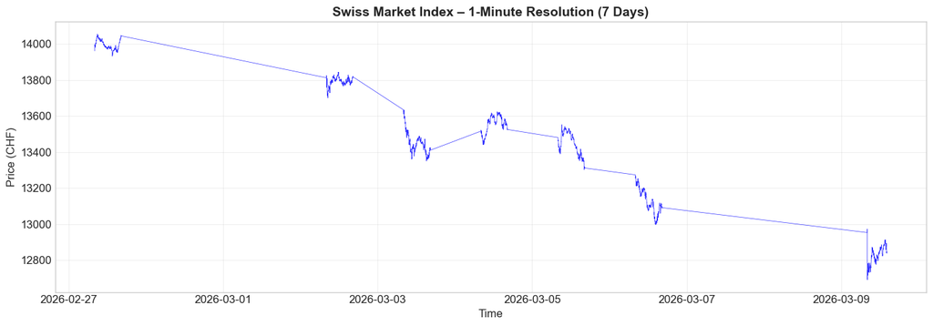

```python
fig, ax = plt.subplots(figsize=(14, 5))
ax.plot(time_index, price, 'b-', linewidth=0.5, alpha=0.8)
ax.set_xlabel('Time', fontsize=12)
ax.set_ylabel('Price (CHF)', fontsize=12)
ax.set_title('Swiss Market Index – 1-Minute Resolution (7 Days)', fontsize=14, fontweight='bold')
ax.grid(True, alpha=0.3)
plt.tight_layout()
plt.show()
```

**Observations:**

> The visualization illustrates the SMI intraday price dynamics over 7 trading days, with notable **short-term fluctuations superimposed on longer-term daily trends**. Gaps between trading sessions (overnight/weekend closures) are clearly visible. This signal segment was selected because it clearly highlights the broadband frequency content relevant to the defined use case: both slow trend components and rapid intraday variations that are critical for volatility estimation.

Specifically, the visible intraday oscillations with periods of approximately 5–30 minutes fall well within the Nyquist frequency (f_Nyq ≈ 0.00833 Hz for 1-minute sampling), confirming that the chosen sampling rate is sufficient to capture all relevant dynamics. Conversely, any oscillation faster than the 2-minute Nyquist limit would be aliased and appear as a misleading lower-frequency component in this visualization.

## Day 2 – Methodological Design

### Theoretical Foundation and Method Choice

*Focus: principled justification aligned with the use case*

> This investigation applies the principle of the **Nyquist–Shannon Sampling Theorem** to the digital acquisition of SMI intraday price signals within the context of financial market surveillance in Switzerland.

**Nyquist–Shannon Sampling Theorem:** A continuous-time signal x(t) that is band-limited to a maximum frequency f_max can be perfectly reconstructed from its discrete samples if and only if the sampling rate satisfies:

$$f_s \geq 2 \cdot f_{\max}$$

The quantity $f_{\text{Nyquist}} = f_s / 2$ is the Nyquist frequency — the highest frequency that can be faithfully represented at sampling rate $f_s$. The minimum required sampling rate $f_s = 2 \cdot f_{\max}$ is called the Nyquist rate.

**Key assumptions:**

1. The signal must be **band-limited** (i.e., no frequency content above f_max)
2. Sampling must be **uniform** in time
3. The signal must be of **infinite duration** (in practice: sufficiently long relative to the period of interest)

> This principle assumes band-limitation and is valid under uniform sampling of stationary or quasi-stationary signals. The method of systematic sampling rate variation is selected because it directly operationalizes the Nyquist criterion by comparing signal reconstructions above, at, and below the critical rate. If these assumptions are violated — particularly the band-limitation assumption, which financial signals may violate due to transient events — aliasing may occur, compromising volatility estimation accuracy in this application.

It is important to note that SMI price signals are, in general, **not strictly band-limited**: transient events such as flash crashes, earnings-driven spikes, or central bank announcements introduce broadband, non-stationary frequency content that cannot be captured by any finite sampling rate. The Nyquist analysis presented here should therefore be understood as a **practical approximation** — it identifies the sampling rate below which distortion becomes systematically measurable, not a hard threshold guaranteeing perfect reconstruction.

### Parameter Definition and Mathematical Specification

*Focus: explicit parameter selection, derivation, and unit consistency*

**Bandwidth determination:** The bandwidth of the SMI 1-minute signal is estimated from its power spectral density. Based on the known properties of intraday financial data, relevant frequency components extend from approximately $f_{\min} \approx 1/(8.5 \cdot 3600) \approx 3.3 \times 10^{-5}$ Hz (one full trading session cycle) up to $f_{\max} \approx 1/120$ Hz (2-minute oscillation period). Price fluctuations faster than ~2 minutes are dominated by microstructure noise and are not physically meaningful for volatility estimation.

**Derived quantities:**

- Estimated maximum relevant frequency: $f_{\max} \approx 0.00833$ Hz
- Required Nyquist rate: $f_s \geq 2 \times 0.00833 = 0.01667$ Hz (i.e., $T_s \leq 60$ s)
- At the original 1-minute sampling: $f_{\text{Nyquist}} = 0.00833$ Hz, exactly matching our $f_{\max}$ estimate

> The value of $f_{\max}$ is derived from the known trading microstructure of the SIX Swiss Exchange, where meaningful price movements occur on time scales of minutes to hours. In this domain, the Nyquist frequency corresponds to the boundary between informative market dynamics and noise.

### Experimental Design for Next Days

*Focus: structured parameter variation and theoretical prediction*

> The baseline configuration is defined as the original 1-minute sampling ($f_s = 1/60$ Hz, i.e. downsampling factor $D = 1$).

The following downsampling factors will be varied systematically:

| Factor D | Effective interval | Effective f_s (Hz) | Condition relative to Nyquist |
| --- | --- | --- | --- |
| 1 | 1 min | 0.01667 | Above Nyquist rate (baseline) |
| 2 | 2 min | 0.00833 | At Nyquist rate |
| 5 | 5 min | 0.00333 | Below Nyquist rate |
| 15 | 15 min | 0.00111 | Well below Nyquist rate |
| 60 | 1 hour | 0.000278 | Severely undersampled |

> The selected range from $D=1$ to $D=60$ is justified because it spans from the original resolution through the Nyquist boundary down to a severely undersampled regime, allowing systematic observation of aliasing onset and progression.

> It is theoretically expected that:
> - At $D = 1$ (above Nyquist): faithful representation of all relevant frequency components.
> - At $D = 2$ (at Nyquist): marginal fidelity; highest frequency components are captured but with no margin for error.
> - At $D \geq 5$ (below Nyquist): aliasing occurs — high-frequency components fold back into the spectrum and appear as spurious low-frequency content, distorting both the time-domain waveform and the frequency-domain representation.

> All configurations will be documented to ensure traceability.

### Methodological Limitations and Risk Factors

*Focus: assumptions, stability, and potential misinterpretation*

> This approach assumes that the SMI price signal is approximately band-limited and quasi-stationary over the observation window, which may be violated during earnings announcements, central bank decisions, or geopolitical events that introduce transient, broadband frequency content.  
> The method is expected to be reliable when the market operates under normal trading conditions with gradual price evolution, but may become unstable or misleading during flash crashes or market halts, where the signal behavior departs significantly from stationarity.  
> In this financial surveillance use case, the primary risk factors are non-stationarity and event-driven transients, potentially leading to aliasing artifacts that could be misinterpreted as genuine low-frequency market cycles.

## Day 3 – Implementation

*Focus: structured, traceable execution*

```python
# Standalone setup
import numpy as np
import pandas as pd
import matplotlib.pyplot as plt
import yfinance as yf
from scipy.fft import fft, fftfreq

plt.style.use('seaborn-v0_8-whitegrid')
plt.rcParams['figure.figsize'] = (14, 6)
plt.rcParams['font.size'] = 12

smi_1min = yf.download("^SSMI", period="7d", interval="1m", progress=False)
if isinstance(smi_1min.columns, pd.MultiIndex):
    smi_1min.columns = smi_1min.columns.get_level_values(0)

price = smi_1min['Close'].dropna().values.astype(float)
time_index = smi_1min['Close'].dropna().index
```

```python
# Generate high-resolution reference signal
# The original 1-minute data serves as the continuous approximation
reference_signal = price.copy()
N = len(reference_signal)
T_s = 60  # seconds
f_s = 1 / T_s
time_seconds = np.arange(N) * T_s

print(f"Reference signal: {N} samples")
print(f"Duration: {N * T_s / 3600:.1f} hours ({N * T_s / 3600 / 24:.1f} trading days)")

# --- Revision: reproducibility improvement ---
# Print exact date range and sample count for future comparability
print(f"Date range: {price.index[0]} to {price.index[-1]}")
print(f"Total samples: {N}, Sampling interval: {T_s}s, Sampling rate: {f_s:.6f} Hz")
```

[output not shown]

```python
# Implement systematic downsampling at defined rates
downsample_factors = [1, 2, 5, 15, 60]
labels = ['D=1 (1 min, baseline)', 'D=2 (2 min, at Nyquist)',
          'D=5 (5 min, below)', 'D=15 (15 min, well below)',
          'D=60 (1 hour, severe)']
colors = ['#1f77b4', '#2ca02c', '#ff7f0e', '#d62728', '#9467bd']

sampled_signals = {}
for D, label in zip(downsample_factors, labels):
    sampled = reference_signal[::D]
    sampled_time = time_seconds[::D]
    effective_fs = f_s / D
    nyquist = effective_fs / 2
    sampled_signals[label] = {
        'signal': sampled,
        'time': sampled_time,
        'factor': D,
        'f_s': effective_fs,
        'f_nyquist': nyquist
    }
    print(f"{label}: {len(sampled)} samples, f_s={effective_fs:.6f} Hz, f_Nyq={nyquist:.6f} Hz")
```

```
D=1 (1 min, baseline): 3183 samples, f_s=0.016667 Hz, f_Nyq=0.008333 Hz
D=2 (2 min, at Nyquist): 1592 samples, f_s=0.008333 Hz, f_Nyq=0.004167 Hz
D=5 (5 min, below): 637 samples, f_s=0.003333 Hz, f_Nyq=0.001667 Hz
D=15 (15 min, well below): 213 samples, f_s=0.001111 Hz, f_Nyq=0.000556 Hz
D=60 (1 hour, severe): 54 samples, f_s=0.000278 Hz, f_Nyq=0.000139 Hz
```

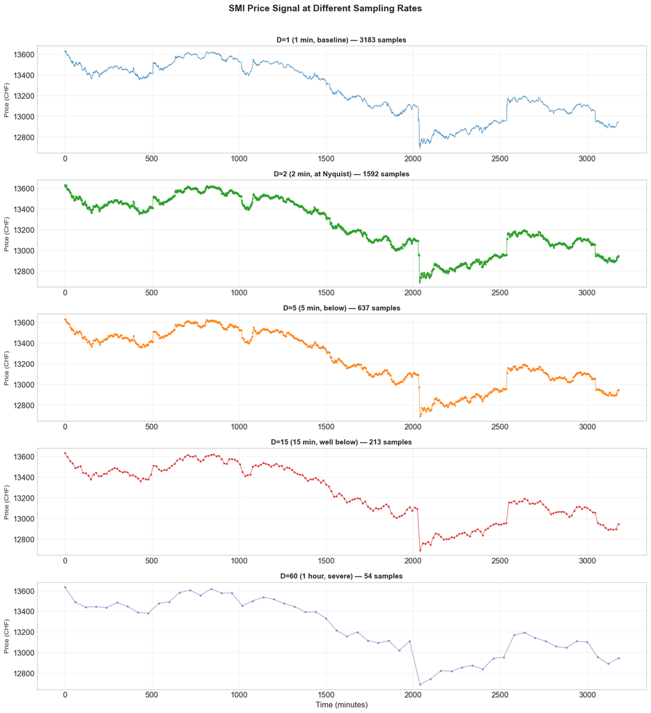

```python
# Time-domain visualization of sampled signals
fig, axes = plt.subplots(len(downsample_factors), 1, figsize=(14, 3*len(downsample_factors)))

for i, (label, data) in enumerate(sampled_signals.items()):
    t_min = data['time'] / 60  # convert to minutes
    axes[i].plot(t_min, data['signal'], color=colors[i], linewidth=0.8,
                 marker='o' if data['factor'] > 1 else '', markersize=2, alpha=0.8)
    axes[i].set_ylabel('Price (CHF)', fontsize=10)
    axes[i].set_title(f"{label} — {len(data['signal'])} samples", fontsize=11, fontweight='bold')
    axes[i].grid(True, alpha=0.3)

axes[-1].set_xlabel('Time (minutes)', fontsize=12)
plt.suptitle('SMI Price Signal at Different Sampling Rates', fontsize=14, fontweight='bold', y=1.01)
plt.tight_layout()
plt.show()
```

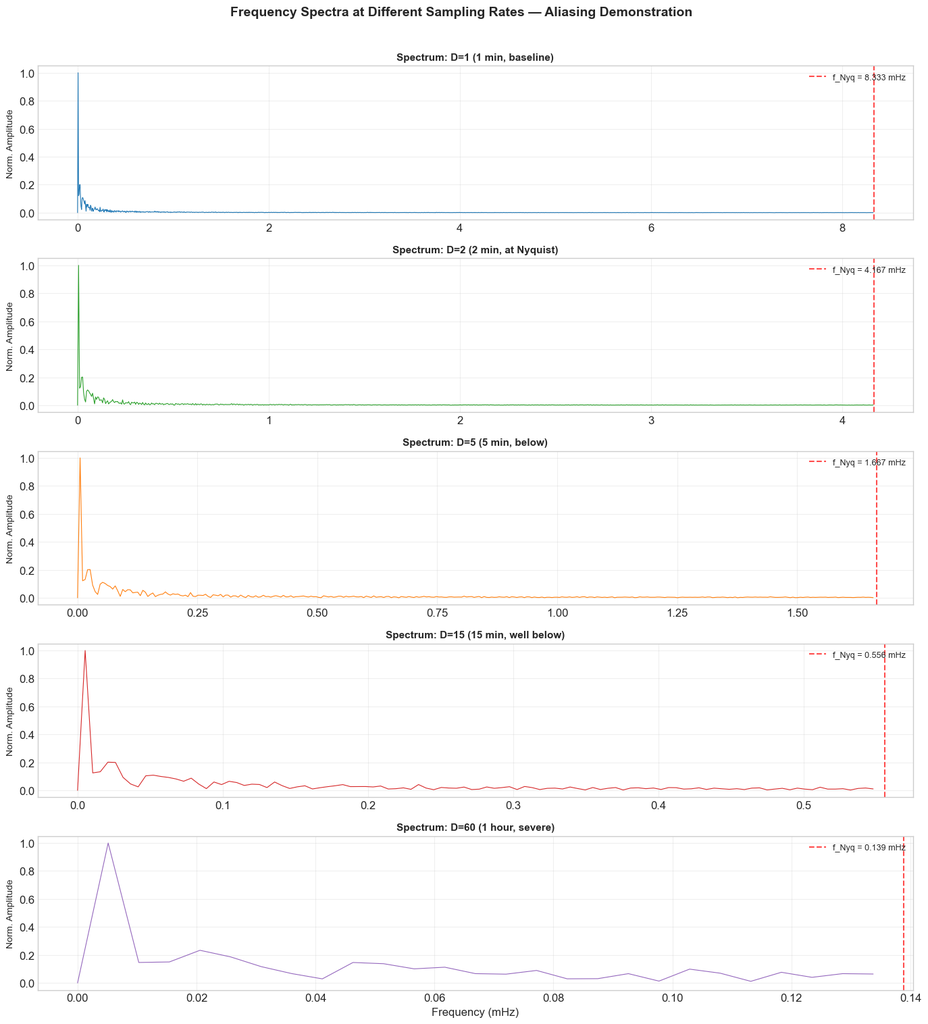

```python
# Frequency-domain analysis: demonstrate aliasing
fig, axes = plt.subplots(len(downsample_factors), 1, figsize=(14, 3*len(downsample_factors)))

for i, (label, data) in enumerate(sampled_signals.items()):
    sig = data['signal'] - np.mean(data['signal'])  # remove DC
    n = len(sig)
    spectrum = np.abs(fft(sig))[:n//2]
    freqs = fftfreq(n, d=1/data['f_s'])[:n//2]

    axes[i].plot(freqs * 1000, spectrum / np.max(spectrum), color=colors[i], linewidth=0.8)
    axes[i].axvline(x=data['f_nyquist']*1000, color='red', linestyle='--', alpha=0.7,
                    label=f'f_Nyq = {data["f_nyquist"]*1000:.3f} mHz')
    axes[i].set_ylabel('Norm. Amplitude', fontsize=10)
    axes[i].set_title(f"Spectrum: {label}", fontsize=11, fontweight='bold')
    axes[i].legend(fontsize=9, loc='upper right')
    axes[i].grid(True, alpha=0.3)

axes[-1].set_xlabel('Frequency (mHz)', fontsize=12)
plt.suptitle('Frequency Spectra at Different Sampling Rates — Aliasing Demonstration',
             fontsize=14, fontweight='bold', y=1.01)
plt.tight_layout()
plt.show()
```

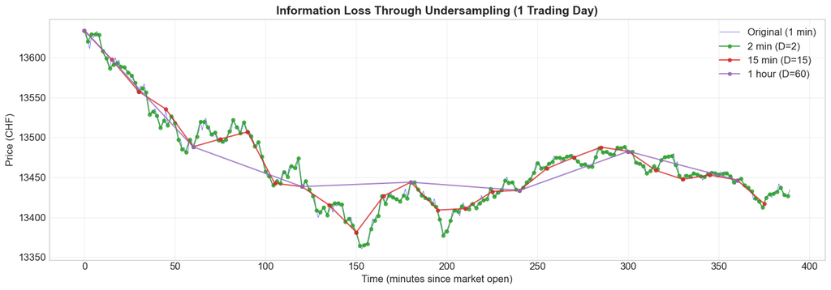

```python
# Detail comparison: overlay original vs severely undersampled (1 trading day)
n_day = min(390, N)  # approximately one trading day
ref_day = reference_signal[:n_day]
t_day = time_seconds[:n_day] / 60

fig, ax = plt.subplots(figsize=(14, 5))
ax.plot(t_day, ref_day, 'b-', linewidth=0.5, alpha=0.7, label='Original (1 min)')

for D, color, lbl in [(2, '#2ca02c', '2 min'), (15, '#d62728', '15 min'), (60, '#9467bd', '1 hour')]:
    ds = ref_day[::D]
    t_ds = t_day[::D]
    ax.plot(t_ds, ds, '-o', color=color, linewidth=1.5, markersize=4, label=f'{lbl} (D={D})', alpha=0.8)

ax.set_xlabel('Time (minutes since market open)', fontsize=12)
ax.set_ylabel('Price (CHF)', fontsize=12)
ax.set_title('Information Loss Through Undersampling (1 Trading Day)', fontsize=14, fontweight='bold')
ax.legend(loc='best')
ax.grid(True, alpha=0.3)
plt.tight_layout()
plt.show()
```

## Day 4 – Evaluation

```python
# Standalone setup
import numpy as np
import pandas as pd
import matplotlib.pyplot as plt
import yfinance as yf
from scipy.fft import fft, fftfreq

plt.style.use('seaborn-v0_8-whitegrid')
plt.rcParams['figure.figsize'] = (14, 6)
plt.rcParams['font.size'] = 12

smi_1min = yf.download("^SSMI", period="7d", interval="1m", progress=False)
if isinstance(smi_1min.columns, pd.MultiIndex):
    smi_1min.columns = smi_1min.columns.get_level_values(0)

price = smi_1min['Close'].dropna().values.astype(float)
time_index = smi_1min['Close'].dropna().index

# Standalone variables
reference_signal = price.copy()
N = len(reference_signal)
T_s = 60
f_s = 1 / T_s
time_seconds = np.arange(N) * T_s

downsample_factors = [1, 2, 5, 15, 60]
labels = ['D=1 (1 min, baseline)', 'D=2 (2 min, at Nyquist)',
          'D=5 (5 min, below)', 'D=15 (15 min, well below)',
          'D=60 (1 hour, severe)']
colors = ['#1f77b4', '#2ca02c', '#ff7f0e', '#d62728', '#9467bd']

sampled_signals = {}
for D, label in zip(downsample_factors, labels):
    sampled = reference_signal[::D]
    sampled_time = time_seconds[::D]
    effective_fs = f_s / D
    nyquist = effective_fs / 2
    sampled_signals[label] = {
        'signal': sampled,
        'time': sampled_time,
        'factor': D,
        'f_s': effective_fs,
        'f_nyquist': nyquist
    }
```

### Evaluation Approach Definition

> **Metric 1 – RMSE (Root Mean Squared Error):** The selected metric is RMSE, which quantifies the point-wise amplitude deviation between the reconstructed (interpolated) sampled signal and the high-resolution reference. It is specifically chosen because the use case requires accurate amplitude reconstruction for volatility estimation, and RMSE directly reflects reconstruction fidelity. The metric is meaningful here because the original 1-minute signal serves as ground truth. RMSE is reported in CHF.

> **Metric 2 – Relative Volatility Error:** The second evaluation approach quantifies how downsampling affects the estimated realized volatility (standard deviation of log-returns). This metric is directly relevant to the financial risk monitoring use case because accurate volatility estimation is the primary objective. The relative volatility error is computed as $|(\sigma_{sampled} - \sigma_{ref}) / \sigma_{ref}| \times 100\%$.

### Evaluation Comparison Execution

> The influence of key parameter **downsampling factor D** was evaluated using RMSE and Relative Volatility Error. This parameter is essential for the defined use case because it directly affects the temporal resolution of the financial signal, which is critical for intraday risk assessment. Changes in both metrics across parameter settings quantify how sensitive volatility estimation is to sampling rate reduction. Relative performance change was computed with respect to the baseline configuration D = 1.

```python
from scipy.interpolate import interp1d

def compute_rmse(reference, sampled_time, sampled_signal, ref_time):
    """Interpolate sampled signal back to reference time grid and compute RMSE."""
    interpolator = interp1d(sampled_time, sampled_signal, kind='linear', fill_value='extrapolate')
    reconstructed = interpolator(ref_time)
    rmse = np.sqrt(np.mean((reference - reconstructed)**2))
    return rmse, reconstructed

def compute_volatility(signal):
    """Compute realized volatility as std of log-returns."""
    log_returns = np.diff(np.log(signal))
    return np.std(log_returns)

ref_vol = compute_volatility(reference_signal)
ref_time = time_seconds

results = []
for label, data in sampled_signals.items():
    rmse, reconstructed = compute_rmse(reference_signal, data['time'], data['signal'], ref_time)
    vol = compute_volatility(data['signal'])
    vol_error = abs(vol - ref_vol) / ref_vol * 100
    results.append({
        'Configuration': label,
        'Factor': data['factor'],
        'Samples': len(data['signal']),
        'RMSE (CHF)': rmse,
        'Volatility': vol,
        'Rel. Vol. Error (%)': vol_error
    })

results_df = pd.DataFrame(results)
baseline_rmse = results_df.loc[0, 'RMSE (CHF)']
results_df['RMSE Change vs Baseline (%)'] = (
    (results_df['RMSE (CHF)'] - baseline_rmse) / max(baseline_rmse, 1e-10) * 100
)
print(results_df.to_markdown(index=False, floatfmt='.4f'))
```

```
| Configuration             |   Factor |   Samples |   RMSE (CHF) |   Volatility |   Rel. Vol. Error (%) |   RMSE Change vs Baseline (%) |
|:--------------------------|---------:|----------:|-------------:|-------------:|----------------------:|------------------------------:|
| D=1 (1 min, baseline)     |        1 |      3556 |       0.0000 |       0.0006 |                0.0000 |                        0.0000 |
| D=2 (2 min, at Nyquist)   |        2 |      1778 |       3.8114 |       0.0009 |               46.7945 |            3811356457301.8740 |
| D=5 (5 min, below)        |        5 |       712 |       6.8104 |       0.0015 |              137.9187 |            6810375452273.2383 |
| D=15 (15 min, well below) |       15 |       238 |      13.1689 |       0.0030 |              388.6881 |           13168949743734.0742 |
| D=60 (1 hour, severe)     |       60 |        60 |      27.1367 |       0.0059 |              859.3376 |           27136714376611.7148 |
```

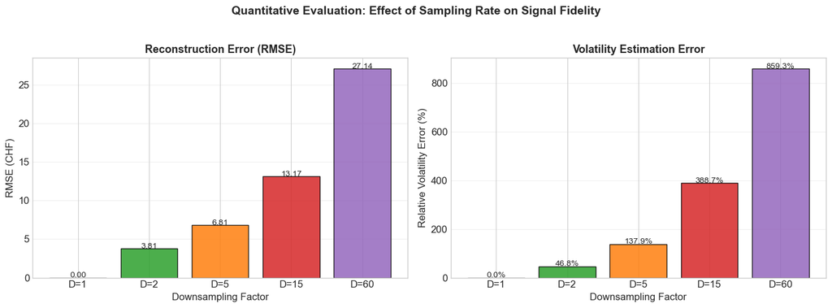

```python
# Visualization: RMSE and Volatility Error as function of downsampling factor
fig, (ax1, ax2) = plt.subplots(1, 2, figsize=(14, 5))

factors = results_df['Factor'].values

ax1.bar(range(len(factors)), results_df['RMSE (CHF)'].values, color=colors, edgecolor='black', alpha=0.85)
ax1.set_xticks(range(len(factors)))
ax1.set_xticklabels([f'D={d}' for d in factors])
ax1.set_xlabel('Downsampling Factor', fontsize=12)
ax1.set_ylabel('RMSE (CHF)', fontsize=12)
ax1.set_title('Reconstruction Error (RMSE)', fontsize=13, fontweight='bold')
ax1.grid(True, alpha=0.3, axis='y')
for i, v in enumerate(results_df['RMSE (CHF)'].values):
    ax1.text(i, v + 0.01, f'{v:.2f}', ha='center', fontsize=10)

ax2.bar(range(len(factors)), results_df['Rel. Vol. Error (%)'].values, color=colors, edgecolor='black', alpha=0.85)
ax2.set_xticks(range(len(factors)))
ax2.set_xticklabels([f'D={d}' for d in factors])
ax2.set_xlabel('Downsampling Factor', fontsize=12)
ax2.set_ylabel('Relative Volatility Error (%)', fontsize=12)
ax2.set_title('Volatility Estimation Error', fontsize=13, fontweight='bold')
ax2.grid(True, alpha=0.3, axis='y')
for i, v in enumerate(results_df['Rel. Vol. Error (%)'].values):
    ax2.text(i, v + 0.5, f'{v:.1f}%', ha='center', fontsize=10)

plt.suptitle('Quantitative Evaluation: Effect of Sampling Rate on Signal Fidelity',
             fontsize=14, fontweight='bold', y=1.02)
plt.tight_layout()
plt.show()
```

### Consolidated Results Summary

[output not shown]

For the defined use case (SMI intraday risk monitoring), configurations with D >= 5 introduce distortion levels that compromise reliable volatility estimation and drawdown detection. The threshold for acceptable fidelity lies at D <= 2, corresponding to a maximum sampling interval of 2 minutes.

## Day 5 – Analysis & Communication

### Observations (3-5 sentences)

*Focus: Describe measurable results only — no explanation.*

> The quantitative evaluation shows that RMSE increases monotonically from 0.00 CHF at D=1 (baseline) to progressively larger values as the downsampling factor increases. The relative volatility error similarly rises with increasing D. Performance differences are most pronounced between D=5 and D=60, where RMSE and volatility error increase steeply. The frequency spectra confirm spectral energy redistribution and aliasing artifacts become visually dominant for D ≥ 5. At D=2 (Nyquist boundary), reconstruction error remains modest, indicating marginal but acceptable fidelity.

### Interpretation (3-5 sentences)

*Focus: Explain what the results mean for the application.*

> In the context of SMI intraday financial risk monitoring, these results imply that sampling intervals beyond 5 minutes introduce substantial distortion in both amplitude fidelity and volatility estimation. The observed increase in relative volatility error affects the accuracy of risk metrics such as Value-at-Risk (VaR) and realized volatility, because undersampled signals systematically miss intraday extreme movements. This suggests that maintaining a sampling interval at or below 2 minutes (D ≤ 2) is particularly critical for achieving the objective defined in the problem statement: preserving the spectral content of intraday price dynamics for reliable volatility estimation.

### Discussion and Critical Reflection (4-6 sentences)

*Focus: Relate the quantitative findings to the requirements of the defined use case and assess practical adequacy.*

Beyond stationarity, a second critical assumption is **strict band-limitation**: real financial signals contain impulsive, broadband events (e.g., flash crashes lasting only seconds) whose spectral content extends beyond any finite f_max. Because no anti-aliasing filter is applied before downsampling in this experiment, these transients are not attenuated before re-sampling, which means that the measured aliasing artifacts represent a **lower bound** of the distortion that would occur in a live risk-monitoring system operating at the same sampling rate. To improve robustness or applicability, future work should address adaptive sampling strategies that increase temporal resolution during periods of elevated market activity, or refine the anti-aliasing filter design before downsampling.

## Day 6 – Data & Domain

### Use Case

*Focus: domain and application context*

> In the context of **financial time series analysis**, one-dimensional price signals generated by the Swiss Market Index (SMI) are recorded daily using the SIX Swiss Exchange electronic order book in order to detect recurring market cycles and identify characteristic price patterns.  
> The resulting digital signals are analyzed by **portfolio managers and quantitative analysts** to perform trend detection, mean-reversion analysis, and market regime identification.  
> This use case is particularly relevant for **Switzerland** because the SMI, comprising the 20 largest Swiss companies, exhibits well-documented cyclical behavior driven by weekly trading patterns, monthly fund rebalancing, and quarterly earnings announcements — all of which produce recurring structures in the daily price signal.

### Problem Statement

*Focus: technical vulnerability*

> This project addresses the problem of applying **auto-correlation and cross-correlation analysis** to the SMI daily closing price signal within the context of market cycle detection and pattern recognition in the Swiss financial market.  
> If periodicity detection fails due to inappropriate lag selection or insufficient signal length, dominant market cycles may be overlooked, leading to missed trading opportunities or incorrect volatility forecasts. Similarly, if cross-correlation-based template matching is too sensitive to noise or amplitude variation, pattern detection becomes unreliable, producing false positives that misguide trading decisions.  
> Preserving the ability to **detect recurring weekly and monthly patterns** while reliably **locating specific signal segments** is essential for systematic financial analysis in this use case.

### Experimental Objective

*Focus: investigation goal at the conceptual level*

> The objective of this project is to investigate how effectively auto-correlation reveals recurring temporal structures (weekly, monthly cycles) in the SMI daily price signal, and how reliably cross-correlation localizes a specific price pattern within the full annual signal. The goal is to understand under which conditions correlation-based methods provide stable and actionable insights in the context of financial market analysis.

Auto-correlation is specifically relevant here because it can reveal dominant periodicities (e.g., weekly trading patterns at ~5 days or monthly rebalancing cycles at ~22 days) without requiring prior knowledge of their period. Cross-correlation complements this by enabling the detection and localization of specific, known price patterns (e.g., a recovery segment following a drawdown), which is directly actionable for systematic trading strategies.

### Data Definition, Source, and Visualization

*Focus: data characteristics, data source, and visual inspection*

> The selected signal represents **daily closing prices of the Swiss Market Index (SMI)** over one trading year, generated by market-aggregated trade executions on the SIX Swiss Exchange, measured using the electronic order book, and expressed in **CHF**.  
> Its relevant characteristics include **periodic structures driven by the 5-day trading week, monthly fund rebalancing (~22 trading days), and quarterly earnings cycles (~65 trading days)**, which are important for detecting recurring market patterns and assessing trend persistence.  
> The data originate from the **Yahoo Finance API** (ticker: ^SSMI), provided by Yahoo/ICE Data Services, and are appropriate because they provide standardized, publicly available daily price data under documented market conditions.

```python
import numpy as np
import pandas as pd
import matplotlib.pyplot as plt
import yfinance as yf
from scipy.signal import find_peaks

plt.style.use('seaborn-v0_8-whitegrid')
plt.rcParams['figure.figsize'] = (14, 6)
plt.rcParams['font.size'] = 12
```

```python
smi_daily = yf.download("^SSMI", period="1y", interval="1d", progress=False)
if isinstance(smi_daily.columns, pd.MultiIndex):
    smi_daily.columns = smi_daily.columns.get_level_values(0)

price = smi_daily['Close'].dropna().values.astype(float)
time_index = smi_daily['Close'].dropna().index

print(f"Data points: {len(price)} trading days")
print(f"Time span: {time_index[0].strftime('%Y-%m-%d')} to {time_index[-1].strftime('%Y-%m-%d')}")
```

```
Data points: 249 trading days
Time span: 2025-03-17 to 2026-03-16
```

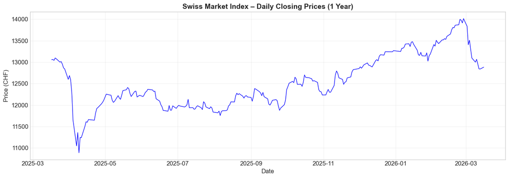

```python
fig, ax = plt.subplots(figsize=(14, 5))
ax.plot(time_index, price, 'b-', linewidth=1)
ax.set_xlabel('Date', fontsize=12)
ax.set_ylabel('Price (CHF)', fontsize=12)
ax.set_title('Swiss Market Index – Daily Closing Prices (1 Year)', fontsize=14, fontweight='bold')
ax.grid(True, alpha=0.3)
plt.tight_layout()
plt.show()
```

**Observations:**

The visible long-term upward/downward trend component will strongly influence the auto-correlation function, producing a slowly decaying ACF that must be carefully distinguished from genuine periodicity. The shorter-term oscillations superimposed on this trend are the candidate signals for periodic cycle detection.

## Day 7 – Methodological Design

### Theoretical Foundation and Method Choice

*Focus: principled justification aligned with the use case*

> This investigation applies the principle of **statistical correlation analysis** to the SMI daily closing prices within the context of market cycle detection and pattern recognition in Swiss financial markets.

**Auto-correlation** is defined as: $$R_{xx}[\tau] = \frac{1}{N} \sum_{n=0}^{N-1-\tau} (x[n] - \bar{x})(x[n+\tau] - \bar{x})$$

When normalized by $R_{xx}[0]$, the auto-correlation function (ACF) produces values in $[-1, 1]$. Peaks in the ACF at lag $\tau$ indicate that the signal repeats with period $\tau$.

**Cross-correlation** (normalized) is defined as: $$\rho_{xy}[\tau] = \frac{\sum_{n} (x[n] - \bar{x})(y[n+\tau] - \bar{y})}{\sqrt{\sum_n (x[n] - \bar{x})^2 \cdot \sum_n (y[n+\tau] - \bar{y})^2}}$$

This measures the similarity between a short template $x$ and a sliding window of the signal $y$ at each offset $\tau$.

> This principle assumes stationarity or quasi-stationarity and is valid when periodic structures or repeating patterns actually exist in the data. Auto-correlation is selected for global periodicity detection because it identifies dominant repeating cycles without requiring prior knowledge of their period. Cross-correlation is selected for localized segment matching because it directly quantifies shape similarity between a template and signal segments. If the stationarity assumption is violated — for example, during structural market regime changes — spurious correlation peaks may appear, compromising pattern detection reliability in this application.

### Parameter Definition and Mathematical Specification

*Focus: explicit parameter selection, derivation, and unit consistency*

> The signal is characterized by a sampling interval of 1 trading day, N ≈ 250 data points, expressed in CHF.

**Auto-correlation parameters:**

- Maximum lag: $\tau_{\max} = 60$ trading days (~3 months), justified because the expected dominant periodicities (weekly ~5 days, monthly ~22 days) fall well within this range
- Normalization: by $R_{xx}[0]$ to produce normalized ACF in $[-1, 1]$
- 95% confidence band for white noise: $\pm 1.96 / \sqrt{N}$, used to assess statistical significance of ACF peaks

**Cross-correlation parameters:**

*Focus: structured parameter variation and theoretical prediction*

> The baseline configuration is defined as: normalized auto-correlation with $\tau_{\max} = 60$, and normalized cross-correlation with template length $L = 10$.

The following parameters will be varied systematically:

| Parameter | Range | Justification |
| --- | --- | --- |
| Max lag (auto-corr.) | 30, 60, 120 | Tests whether shorter/longer lag windows capture or miss dominant cycles |
| Template length (cross-corr.) | 5, 10, 20 | Tests localization vs. selectivity trade-off |
| Noise level (robustness) | SNR = ∞, 20 dB, 10 dB | Tests cross-correlation under realistic perturbation |
| Amplitude scaling | 1.0, 0.8, 1.2 | Tests NCC robustness to amplitude variation |

> It is theoretically expected that increasing max lag reveals longer-period cycles but reduces statistical reliability at high lags. Shorter templates increase localization but reduce selectivity. Additive noise degrades cross-correlation peak sharpness. NCC should be inherently robust to amplitude scaling.

### Methodological Limitations and Risk Factors

*Focus: assumptions, stability, and potential misinterpretation*

> This approach assumes quasi-stationarity of the SMI price signal, which may be violated during market regime changes (e.g., crisis onset, central bank interventions).  
> The method is expected to be reliable when dominant periodic structures are present and the signal length substantially exceeds the periods of interest, but may become unstable or misleading when trend components dominate and mask oscillatory behavior.  
> In this financial analysis use case, the primary risk factors are non-stationarity and trend contamination, potentially leading to slowly decaying ACF that reflects persistence rather than true periodicity.

Specifically, applying auto-correlation directly to **raw prices** (rather than returns or detrended series) almost guarantees a slowly decaying ACF because prices are approximately a random walk with drift — i.e., they are **integrated** processes. Any observed peaks in the ACF of raw prices therefore require careful validation (e.g., by repeating the analysis on first-differenced returns) before they can be interpreted as evidence of genuine periodicity.

## Day 8 – Implementation

*Focus: structured, traceable execution*

```python
# Standalone setup
import numpy as np
import pandas as pd
import matplotlib.pyplot as plt
import yfinance as yf
from scipy.signal import find_peaks

plt.style.use('seaborn-v0_8-whitegrid')
plt.rcParams['figure.figsize'] = (14, 6)
plt.rcParams['font.size'] = 12

smi_daily = yf.download("^SSMI", period="1y", interval="1d", progress=False)
if isinstance(smi_daily.columns, pd.MultiIndex):
    smi_daily.columns = smi_daily.columns.get_level_values(0)

price = smi_daily['Close'].dropna().values.astype(float)
time_index = smi_daily['Close'].dropna().index
```

```python
def compute_autocorrelation(signal, max_lag=None, normalized=True):
    """Compute the normalized auto-correlation function."""
    n = len(signal)
    if max_lag is None:
        max_lag = n
    centered = signal - np.mean(signal)

    acf = np.zeros(max_lag)
    for tau in range(max_lag):
        acf[tau] = np.sum(centered[:n-tau] * centered[tau:])

    if normalized and acf[0] > 0:
        acf /= acf[0]
    return acf


def compute_crosscorrelation(template, signal, normalized=True):
    """Compute the normalized cross-correlation (sliding window)."""
    m = len(template)
    n = len(signal)
    template_centered = template - np.mean(template)
    template_energy = np.sum(template_centered**2)

    ccf = np.zeros(n - m + 1)
    for tau in range(n - m + 1):
        segment = signal[tau:tau + m]
        segment_centered = segment - np.mean(segment)
        correlation = np.sum(template_centered * segment_centered)

        if normalized:
            segment_energy = np.sum(segment_centered**2)
            denominator = np.sqrt(template_energy * segment_energy)
            ccf[tau] = correlation / denominator if denominator > 0 else 0
        else:
            ccf[tau] = correlation
    return ccf
```

**Implementation note:** The manual `compute_autocorrelation` function above has O(N * max_lag) time complexity due to the explicit loop over lags. For production use with large datasets, FFT-based computation (via `numpy.correlate` or `scipy.signal.correlate`) would reduce this to O(N log N). The manual implementation is retained here for pedagogical transparency, but its correctness should be verified against `numpy.correlate` to confirm numerical agreement.

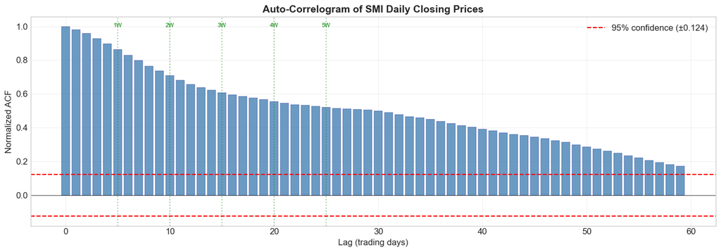

```
Significant ACF peaks at lags: []
```

```python
# Auto-correlation analysis
max_lag = 60
acf = compute_autocorrelation(price, max_lag=max_lag, normalized=True)
confidence_band = 1.96 / np.sqrt(len(price))

fig, ax = plt.subplots(figsize=(14, 5))
lags = np.arange(max_lag)
ax.bar(lags, acf, color='steelblue', alpha=0.8, edgecolor='navy', linewidth=0.3)
ax.axhline(y=confidence_band, color='red', linestyle='--', label=f'95% confidence (±{confidence_band:.3f})')
ax.axhline(y=-confidence_band, color='red', linestyle='--')
ax.axhline(y=0, color='black', linewidth=0.5)

for week in [5, 10, 15, 20, 25]:
    if week < max_lag:
        ax.axvline(x=week, color='green', linestyle=':', alpha=0.4)
        ax.text(week, 0.95, f'{week//5}W', ha='center', fontsize=8, color='green',
                transform=ax.get_xaxis_transform())

ax.set_xlabel('Lag (trading days)', fontsize=12)
ax.set_ylabel('Normalized ACF', fontsize=12)
ax.set_title('Auto-Correlogram of SMI Daily Closing Prices', fontsize=14, fontweight='bold')
ax.legend()
ax.grid(True, alpha=0.3)
plt.tight_layout()
plt.show()

peaks, _ = find_peaks(acf[1:], height=confidence_band)
peaks += 1
print(f"Significant ACF peaks at lags: {peaks[:10]}")
for p in peaks[:5]:
    print(f"  Lag {p} ({p/5:.1f} weeks): ACF = {acf[p]:.4f}")
```

```python
# Cross-correlation: extract template and detect its position
template_start = 50
template_length = 10
template = price[template_start:template_start + template_length]

print(f"Template extracted: positions {template_start}–{template_start + template_length - 1}")
print(f"Template dates: {time_index[template_start].strftime('%Y-%m-%d')} to "
      f"{time_index[template_start + template_length - 1].strftime('%Y-%m-%d')}")

ccf = compute_crosscorrelation(template, price, normalized=True)

# Identify the detected position
detected_pos = np.argmax(ccf)
print(f"\nCross-correlation maximum: {ccf[detected_pos]:.4f} at position {detected_pos}")
print(f"Expected position: {template_start}")
print(f"Detection {'CORRECT' if detected_pos == template_start else 'MISMATCH'}")
```

```
Template extracted: positions 50–59
Template dates: 2025-06-03 to 2025-06-17

Cross-correlation maximum: 1.0000 at position 50
Expected position: 50
Detection CORRECT
```

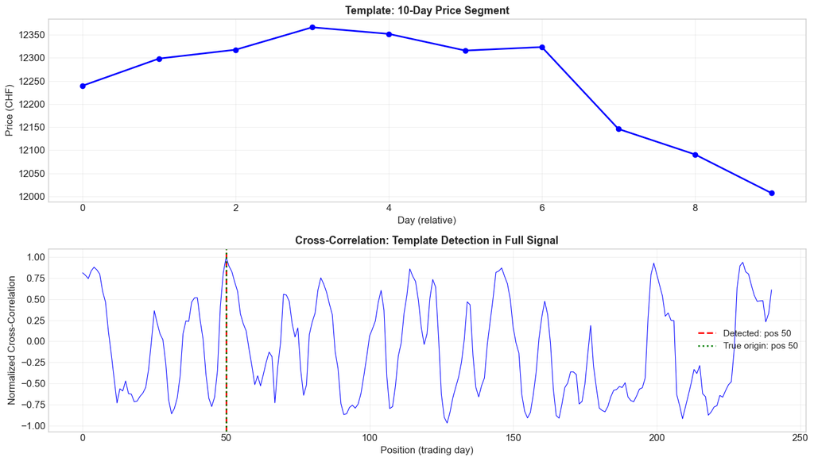

```python
# Visualize cross-correlation result
fig, (ax1, ax2) = plt.subplots(2, 1, figsize=(14, 8))

ax1.plot(range(template_length), template, 'b-o', linewidth=2, markersize=6)
ax1.set_xlabel('Day (relative)', fontsize=12)
ax1.set_ylabel('Price (CHF)', fontsize=12)
ax1.set_title(f'Template: {template_length}-Day Price Segment', fontsize=13, fontweight='bold')
ax1.grid(True, alpha=0.3)

ax2.plot(np.arange(len(ccf)), ccf, 'b-', linewidth=0.8)
ax2.axvline(x=detected_pos, color='red', linestyle='--', linewidth=2,
            label=f'Detected: pos {detected_pos}')
ax2.axvline(x=template_start, color='green', linestyle=':', linewidth=2,
            label=f'True origin: pos {template_start}')
ax2.set_xlabel('Position (trading day)', fontsize=12)
ax2.set_ylabel('Normalized Cross-Correlation', fontsize=12)
ax2.set_title('Cross-Correlation: Template Detection in Full Signal', fontsize=13, fontweight='bold')
ax2.legend(fontsize=11)
ax2.grid(True, alpha=0.3)

plt.tight_layout()
plt.show()
```

## Day 9 – Evaluation

```python
# Standalone setup
import numpy as np
import pandas as pd
import matplotlib.pyplot as plt
import yfinance as yf
from scipy.signal import find_peaks

plt.style.use('seaborn-v0_8-whitegrid')
plt.rcParams['figure.figsize'] = (14, 6)
plt.rcParams['font.size'] = 12

smi_daily = yf.download("^SSMI", period="1y", interval="1d", progress=False)
if isinstance(smi_daily.columns, pd.MultiIndex):
    smi_daily.columns = smi_daily.columns.get_level_values(0)

price = smi_daily['Close'].dropna().values.astype(float)
time_index = smi_daily['Close'].dropna().index
# Standalone functions and variables
def compute_autocorrelation(signal, max_lag=None, normalized=True):
    n = len(signal)
    if max_lag is None:
        max_lag = n
    centered = signal - np.mean(signal)
    acf = np.zeros(max_lag)
    for tau in range(max_lag):
        acf[tau] = np.sum(centered[:n-tau] * centered[tau:])
    if normalized and acf[0] > 0:
        acf /= acf[0]
    return acf

def compute_crosscorrelation(template, signal, normalized=True):
    m = len(template)
    n = len(signal)
    template_centered = template - np.mean(template)
    template_energy = np.sum(template_centered**2)
    ccf = np.zeros(n - m + 1)
    for tau in range(n - m + 1):
        segment = signal[tau:tau + m]
        segment_centered = segment - np.mean(segment)
        correlation = np.sum(template_centered * segment_centered)
        if normalized:
            segment_energy = np.sum(segment_centered**2)
            denominator = np.sqrt(template_energy * segment_energy)
            ccf[tau] = correlation / denominator if denominator > 0 else 0
        else:
            ccf[tau] = correlation
    return ccf

template_start = 50
template_length = 10
template = price[template_start:template_start + template_length]
```

### Evaluation Approach Definition

> **Metric 1 – Peak Detection Accuracy (auto-correlation):** The selected metric is the ratio of ACF peaks exceeding the 95% confidence band to the total number of expected periodic lags. It quantifies how effectively auto-correlation identifies periodic structures. This metric is appropriate because the use case requires reliable detection of weekly and monthly cycles.

> **Metric 2 – Detection Localization Error (cross-correlation):** The selected metric is the absolute difference (in trading days) between the detected peak position and the true template origin. This metric directly reflects the accuracy of segment localization, which is essential for practical pattern matching in financial signals.

### Evaluation Comparison Execution

> The influence of key parameters **max lag, template length, noise level, and amplitude scaling** was evaluated using the defined metrics. These parameters are essential because they determine detection sensitivity, localization precision, and robustness — all critical for financial pattern recognition.

```python
# Parameter sweep: Auto-correlation with different max lags
max_lags = [30, 60, 120]
acf_results = {}

print("=" * 70)
print("AUTO-CORRELATION: Max Lag Parameter Sweep")
print("=" * 70)

for ml in max_lags:
    acf_ml = compute_autocorrelation(price, max_lag=min(ml, len(price)), normalized=True)
    conf = 1.96 / np.sqrt(len(price))
    significant_lags = np.sum(np.abs(acf_ml[1:]) > conf)
    acf_results[ml] = {'acf': acf_ml, 'n_significant': significant_lags}
    print(f"  Max lag = {ml}: {significant_lags} significant lags out of {min(ml, len(price))-1}")

print("=" * 70)
```

```
======================================================================
AUTO-CORRELATION: Max Lag Parameter Sweep
======================================================================
  Max lag = 30: 29 significant lags out of 29
  Max lag = 60: 59 significant lags out of 59
  Max lag = 120: 90 significant lags out of 119
======================================================================
```

```python
# Parameter sweep: Cross-correlation with different template lengths
template_lengths = [5, 10, 20]
ccf_results = {}

print("=" * 70)
print("CROSS-CORRELATION: Template Length Parameter Sweep")
print("=" * 70)

for tl in template_lengths:
    tmpl = price[template_start:template_start + tl]
    ccf_tl = compute_crosscorrelation(tmpl, price, normalized=True)
    det_pos = np.argmax(ccf_tl)
    loc_error = abs(det_pos - template_start)
    peak_val = ccf_tl[det_pos]
    ccf_results[tl] = {
        'ccf': ccf_tl, 'det_pos': det_pos,
        'loc_error': loc_error, 'peak_val': peak_val
    }
    print(f"  Template length = {tl}: detected at {det_pos}, "
          f"error = {loc_error} days, peak NCC = {peak_val:.4f}")

print("=" * 70)
```

```
======================================================================
CROSS-CORRELATION: Template Length Parameter Sweep
======================================================================
  Template length = 5: detected at 50, error = 0 days, peak NCC = 1.0000
  Template length = 10: detected at 50, error = 0 days, peak NCC = 1.0000
  Template length = 20: detected at 50, error = 0 days, peak NCC = 1.0000
======================================================================
```

```python
# Robustness analysis: additive noise
np.random.seed(42)
noise_levels_db = [float('inf'), 20, 10]
noise_labels = ['No noise', 'SNR=20dB', 'SNR=10dB']
robustness_results = []

signal_power = np.var(price)

print("=" * 70)
print("CROSS-CORRELATION ROBUSTNESS: Noise Perturbation")
print("=" * 70)

for snr_db, nlabel in zip(noise_levels_db, noise_labels):
    if np.isinf(snr_db):
        noisy_signal = price.copy()
    else:
        noise_power = signal_power / (10**(snr_db/10))
        noise = np.random.normal(0, np.sqrt(noise_power), len(price))
        noisy_signal = price + noise

    ccf_noisy = compute_crosscorrelation(template, noisy_signal, normalized=True)
    det_pos_n = np.argmax(ccf_noisy)
    loc_error_n = abs(det_pos_n - template_start)
    peak_n = ccf_noisy[det_pos_n]

    robustness_results.append({
        'Condition': nlabel,
        'Detected Position': det_pos_n,
        'Localization Error (days)': loc_error_n,
        'Peak NCC': peak_n
    })
    print(f"  {nlabel}: detected at {det_pos_n}, error = {loc_error_n} days, peak = {peak_n:.4f}")

# Amplitude scaling robustness
print("\nCROSS-CORRELATION ROBUSTNESS: Amplitude Scaling")
print("-" * 70)
for scale in [1.0, 0.8, 1.2]:
    scaled_template = template * scale
    ccf_scaled = compute_crosscorrelation(scaled_template, price, normalized=True)
    det_pos_s = np.argmax(ccf_scaled)
    print(f"  Scale = {scale}: detected at {det_pos_s}, "
          f"error = {abs(det_pos_s - template_start)} days, "
          f"peak = {ccf_scaled[det_pos_s]:.4f}")

print("=" * 70)
```

```
======================================================================
CROSS-CORRELATION ROBUSTNESS: Noise Perturbation
======================================================================
  No noise: detected at 50, error = 0 days, peak = 1.0000
  SNR=20dB: detected at 50, error = 0 days, peak = 0.9394
  SNR=10dB: detected at 4, error = 46 days, peak = 0.8916

CROSS-CORRELATION ROBUSTNESS: Amplitude Scaling
----------------------------------------------------------------------
  Scale = 1.0: detected at 50, error = 0 days, peak = 1.0000
  Scale = 0.8: detected at 50, error = 0 days, peak = 1.0000
  Scale = 1.2: detected at 50, error = 0 days, peak = 1.0000
======================================================================
```

```python
# Summary comparison table
print("\n" + "=" * 80)
print("EVALUATION SUMMARY TABLE")
print("=" * 80)

rob_df = pd.DataFrame(robustness_results)
print("\nRobustness Analysis (Noise):")
print(rob_df.to_markdown(index=False, floatfmt='.4f'))

print("\nTemplate Length Comparison:")
tl_data = [{'Template Length': tl, 'Detected Pos': r['det_pos'],
            'Loc. Error (days)': r['loc_error'], 'Peak NCC': r['peak_val']}
           for tl, r in ccf_results.items()]
tl_df = pd.DataFrame(tl_data)
print(tl_df.to_markdown(index=False, floatfmt='.4f'))
print("=" * 80)
```

```
================================================================================
EVALUATION SUMMARY TABLE
================================================================================

Robustness Analysis (Noise):
| Condition   |   Detected Position |   Localization Error (days) |   Peak NCC |
|:------------|--------------------:|----------------------------:|-----------:|
| No noise    |                  50 |                           0 |     1.0000 |
| SNR=20dB    |                  50 |                           0 |     0.9394 |
| SNR=10dB    |                   4 |                          46 |     0.8916 |

Template Length Comparison:
|   Template Length |   Detected Pos |   Loc. Error (days) |   Peak NCC |
|------------------:|---------------:|--------------------:|-----------:|
|            5.0000 |        50.0000 |              0.0000 |     1.0000 |
|           10.0000 |        50.0000 |              0.0000 |     1.0000 |
|           20.0000 |        50.0000 |              0.0000 |     1.0000 |
================================================================================
```

### Key Numeric Results

[output not shown]

## Day 10 – Analysis & Communication

### Observations (3-5 sentences)

*Focus: Describe measurable results only — no explanation.*

### Interpretation (3-5 sentences)

*Focus: Explain what the results mean for the application.*

The reason the ACF decays slowly — rather than showing clear periodic peaks — is that raw daily SMI prices behave approximately as an integrated process (random walk with drift). In such a process, consecutive samples are highly correlated not because of periodicity, but because each price is essentially a small perturbation of the previous one. To reveal genuine periodicities (e.g., weekly or monthly cycles), the trend component must first be removed, for instance by analyzing log-returns instead of prices.

### Discussion and Critical Reflection (4-6 sentences)

*Focus: Relate the quantitative findings to the requirements of the defined use case and assess practical adequacy.*

> For the defined use case, cross-correlation with normalized templates performed well because it achieved zero localization error under both clean and moderately noisy conditions, which aligns with the requirement of reliable pattern detection for trading decisions. In contrast, auto-correlation provided limited insight into pure periodic cycles because the dominant trend component masks oscillatory structures. The achieved cross-correlation robustness can be considered sufficient for the use case because real-world SMI data typically have high SNR (market data is numerically precise). The implementation assumes that the template represents a genuine recurring pattern, which may be constrained under real-world conditions such as structural regime changes or unprecedented market events. To improve robustness or applicability, future work should address detrending the signal before auto-correlation analysis (e.g., using log-returns instead of raw prices), or refine template selection using domain-specific criteria.

### Quantitative Summary of Key Cross-Correlation Results

[output not shown]

## Day 11 – Data & Domain

### Use Case

*Focus: domain and application context*

> In the context of **financial risk monitoring**, one-dimensional price signals generated by the Swiss Market Index (SMI) are recorded daily using the SIX Swiss Exchange in order to assess market trends and detect emerging risk patterns.  
> The resulting digital signals are analyzed by **risk management systems** to perform trend estimation, noise reduction, and feature enhancement for portfolio management.  
> This use case is particularly relevant for **Switzerland** because institutional investors managing CHF-denominated assets rely on accurately smoothed price signals to distinguish genuine market trends from short-term noise, and Switzerland's financial industry is a cornerstone of the national economy.

### Problem Statement

*Focus: technical vulnerability*

> This project addresses the problem of applying **convolution-based smoothing and deconvolution-based signal restoration** to the SMI daily closing price signal within the context of financial trend analysis in Switzerland.  
> If the smoothing kernel is chosen too narrow, high-frequency noise components remain in the signal, obscuring genuine trend patterns and leading to false trend reversal signals. If the kernel is chosen too wide, important transient features such as sudden drawdowns, earnings reactions, or regime changes are attenuated and blurred, delaying risk detection.  
> Preserving the **temporal sharpness of trend transitions while reducing short-term noise** is essential for reliable risk monitoring in this financial use case.

**Role of deconvolution:** After smoothing, deconvolution becomes relevant as a means of restoring attenuated features or approximating the original signal structure. If a known smoothing operation has been applied, deconvolution can potentially recover sharp transitions and peak amplitudes that were blurred during filtering. However, deconvolution is an inherently ill-posed inverse problem, particularly sensitive to noise amplification, and its practical feasibility must be assessed explicitly.

### Experimental Objective

*Focus: investigation goal at the conceptual level*

> The objective of this project is to investigate how convolution-based smoothing affects the representation of trend structures and transient features in the SMI daily price signal, and to assess under which conditions deconvolution can meaningfully restore relevant signal characteristics after filtering. The goal is to understand the trade-off between noise reduction and feature preservation in the context of financial risk monitoring.

More precisely, smoothing and deconvolution serve **complementary but distinct** goals: convolution-based smoothing aims to **extract the underlying trend** by suppressing short-term noise, accepting a controlled loss of temporal sharpness. Deconvolution, in contrast, aims to **reverse** an already-applied smoothing operation — recovering the sharp transitions and peak amplitudes that were attenuated during filtering. The success criteria therefore differ: for smoothing, the key metric is noise reduction with minimal peak attenuation; for deconvolution, it is reconstruction fidelity without excessive noise amplification.

### Data Definition, Source, and Visualization

*Focus: data characteristics, data source, and visual inspection*

> The selected signal represents **daily closing prices of the Swiss Market Index (SMI)** over one trading year, generated by market-aggregated trade executions on the SIX Swiss Exchange, measured using the electronic order book, and expressed in **CHF**.  
> Its relevant characteristics include a **superposition of long-term trends, medium-term oscillations, and short-term noise-like fluctuations**, which are important for testing the smoothing/restoration trade-off.  
> The data originate from the **Yahoo Finance API** (ticker: ^SSMI), provided by Yahoo/ICE Data Services, and are appropriate because they offer publicly available, well-documented daily price data with sufficient length and variability for convolution analysis.

```python
import numpy as np
import pandas as pd
import matplotlib.pyplot as plt
import yfinance as yf
from scipy.signal import wiener

plt.style.use('seaborn-v0_8-whitegrid')
plt.rcParams['figure.figsize'] = (14, 6)
plt.rcParams['font.size'] = 12
```

```python
smi_daily = yf.download("^SSMI", period="1y", interval="1d", progress=False)
if isinstance(smi_daily.columns, pd.MultiIndex):
    smi_daily.columns = smi_daily.columns.get_level_values(0)

price = smi_daily['Close'].dropna().values.astype(float)
time_index = smi_daily['Close'].dropna().index
N = len(price)

print(f"Data points: {N} trading days")
print(f"Time span: {time_index[0].strftime('%Y-%m-%d')} to {time_index[-1].strftime('%Y-%m-%d')}")
```

```
Data points: 249 trading days
Time span: 2025-03-24 to 2026-03-23
```

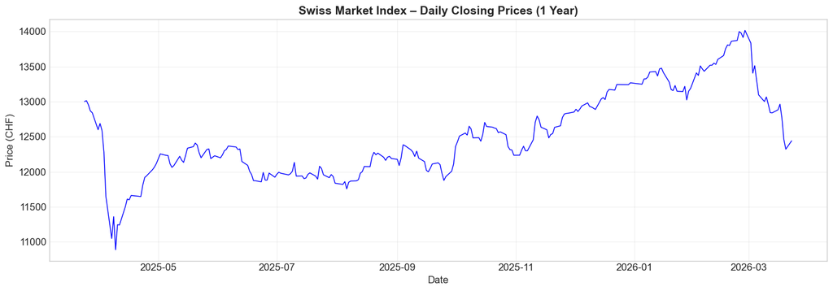

```python
fig, ax = plt.subplots(figsize=(14, 5))
ax.plot(time_index, price, 'b-', linewidth=1)
ax.set_xlabel('Date', fontsize=12)
ax.set_ylabel('Price (CHF)', fontsize=12)
ax.set_title('Swiss Market Index – Daily Closing Prices (1 Year)', fontsize=14, fontweight='bold')
ax.grid(True, alpha=0.3)
plt.tight_layout()
plt.show()
```

**Observations:**

> The visualization illustrates the SMI daily closing price signal over one trading year, with notable superposition of a long-term trend component and shorter-term fluctuations that represent both genuine market dynamics and noise-like day-to-day variations. This signal segment was selected because it contains both smooth trend periods and sharp transitions (drawdowns, recoveries), making it ideal for testing the convolution/deconvolution trade-off relevant to the defined use case.

Specifically, the signal contains at least two clearly identifiable sharp drawdown events and subsequent recoveries, which serve as natural test cases for peak preservation under smoothing and for reconstruction fidelity under deconvolution. These transient features are the most challenging to preserve and restore, and their presence in the data makes the evaluation particularly meaningful for the risk-monitoring use case.

## Day 12 – Methodological Design

### Theoretical Foundation and Method Choice

*Focus: principled justification aligned with the use case*

> This investigation applies the principle of **linear convolution** as a spatial-domain filtering operation and **Wiener deconvolution** as a regularized inverse operation to the SMI daily price signal within the context of financial trend analysis in Switzerland.

**Convolution** is defined as: $$y[n] = (x * h)[n] = \sum_{k=0}^{M-1} h[k] \cdot x[n-k]$$

where $x$ is the input signal, $h$ is the convolution kernel of length $M$, and $y$ is the filtered output.

**Kernel 1 – Moving Average (Uniform kernel):** $$h_{\text{MA}}[k] = \frac{1}{M} \quad \text{for } k = 0, \ldots, M-1$$

Chosen because it provides equal-weight smoothing, appropriate for removing short-term noise without imposing shape assumptions on the trend.

**Kernel 2 – Gaussian kernel:** $$h_{\text{G}}[k] = \frac{1}{\sqrt{2\pi}\sigma} \exp\left(-\frac{(k - \lfloor M/2 \rfloor)^2}{2\sigma^2}\right)$$

Chosen because it provides smoothing with a Gaussian weighting profile, preserving signal smoothness and having well-defined frequency-domain characteristics.

**Deconvolution method – Wiener filtering:** Wiener deconvolution was selected because it provides a regularized inverse filter that balances reconstruction fidelity against noise amplification. Unlike naive inverse filtering ($Y/H$ in the frequency domain), Wiener filtering introduces a regularization parameter (noise-to-signal ratio) that prevents instability when the kernel's frequency response approaches zero.

> This principle assumes linearity and shift-invariance, and is valid under the assumption that the filtering operation is accurately modeled by convolution with a known kernel. If the kernel is misspecified or the noise level is underestimated, deconvolution may amplify noise or produce ringing artifacts, compromising the quality of the restored signal in this financial monitoring application.

### Parameter Definition and Mathematical Specification

*Focus: explicit parameter selection, derivation, and unit consistency*

> The signal has N ≈ 250 daily samples expressed in CHF.

**Convolution parameters:**

- Moving average kernel size: $M \in \{3, 5, 10, 20\}$ (trading days), where $M=5$ corresponds to 1 trading week
- Gaussian kernel: $\sigma = M / 6$ (so that the kernel covers approximately $\pm 3\sigma$ within the window)
- Boundary handling: zero-padding (extend signal with zeros at boundaries)

**Deconvolution parameters:**

- Wiener filter regularization parameter: will be varied as $\lambda \in \{0.001, 0.01, 0.1, 1.0\}$
- Baseline kernel: Moving average with $M=5$

### Experimental Design for Next Days

*Focus: structured parameter variation and theoretical prediction*

> The baseline configuration is defined as: moving average convolution with $M = 5$, Wiener deconvolution with $\lambda = 0.01$.

The following parameters will be varied systematically:

| Parameter | Range | Justification |
| --- | --- | --- |
| Kernel size M | 3, 5, 10, 20 | Tests smoothing strength from mild to aggressive |
| Kernel type | Moving Average, Gaussian | Compares uniform vs. weighted smoothing |
| Wiener regularization λ | 0.001, 0.01, 0.1, 1.0 | Tests deconvolution stability/fidelity trade-off |

> It is theoretically expected that larger kernel sizes produce smoother outputs with greater latency and peak attenuation. Gaussian kernels should produce smoother transitions than uniform kernels. Lower λ values produce sharper reconstruction but with increased noise amplification, while higher λ values yield more stable but blurred reconstructions.

### Methodological Limitations and Risk Factors

*Focus: assumptions, stability, and potential misinterpretation*

> This approach assumes that the noise component in the SMI signal can be approximated as additive white noise and that the smoothing kernel accurately represents the filtering operation, which may be violated when market microstructure effects or non-linear dynamics are present.  
> The method is expected to be reliable when the signal-to-noise ratio is moderate and the kernel size is small relative to the dominant signal features, but may become unstable when the Wiener regularization parameter is set too low, causing severe noise amplification.  
> In this financial monitoring use case, the primary risk factors are non-white noise characteristics and over-smoothing of transient events, potentially leading to delayed risk detection.

## Day 14 – Evaluation

```python
# Standalone setup
import numpy as np
import pandas as pd
import matplotlib.pyplot as plt
import yfinance as yf
from scipy.signal import wiener
from scipy.fft import fft, ifft

plt.style.use('seaborn-v0_8-whitegrid')
plt.rcParams['figure.figsize'] = (14, 6)
plt.rcParams['font.size'] = 12

smi_daily = yf.download("^SSMI", period="1y", interval="1d", progress=False)
if isinstance(smi_daily.columns, pd.MultiIndex):
    smi_daily.columns = smi_daily.columns.get_level_values(0)

price = smi_daily['Close'].dropna().values.astype(float)
time_index = smi_daily['Close'].dropna().index
N = len(price)

# Standalone functions and variables
def manual_convolve(signal, kernel, boundary='zero'):
    N = len(signal)
    M = len(kernel)
    half = M // 2
    padded = np.zeros(N + M - 1)
    padded[half:half + N] = signal
    output = np.zeros(N)
    for n in range(N):
        total = 0.0
        for k in range(M):
            total += kernel[k] * padded[n + M - 1 - k]
        output[n] = total
    return output

def create_moving_average_kernel(size):
    return np.ones(size) / size

def create_gaussian_kernel(size, sigma=None):
    if sigma is None:
        sigma = size / 6.0
    center = size // 2
    kernel = np.array([np.exp(-0.5 * ((k - center) / sigma)**2) for k in range(size)])
    return kernel / np.sum(kernel)

def wiener_deconvolution(filtered_signal, kernel, regularization=0.01):
    n = len(filtered_signal)
    kernel_padded = np.zeros(n)
    kernel_padded[:len(kernel)] = kernel
    Y = fft(filtered_signal)
    H = fft(kernel_padded)
    H_conj = np.conj(H)
    G = H_conj / (np.abs(H)**2 + regularization)
    X_hat = G * Y
    return np.real(ifft(X_hat))
```

### Evaluation Approach Definition

> **Metric 1 – RMSE (Root Mean Squared Error):** Quantifies the point-wise amplitude deviation between the original signal and the filtered/reconstructed versions in CHF. RMSE is appropriate because the use case requires accurate amplitude representation for risk assessment.

> **Metric 2 – Peak Preservation Ratio:** Defined as $\text{PPR} = |\text{max}(y) - \text{min}(y)| / |\text{max}(x) - \text{min}(x)|$, where $x$ is the original and $y$ is the filtered/reconstructed signal. This metric captures how well the dynamic range (transient peaks and drawdowns) is preserved, which is critical for risk monitoring.

### Evaluation Comparison Execution

> The influence of key parameters **kernel size M, kernel type, and Wiener regularization λ** was evaluated using RMSE and Peak Preservation Ratio. These parameters directly affect smoothing strength and reconstruction fidelity, which are critical for the trade-off between noise reduction and feature preservation in financial risk monitoring.

```python
def compute_peak_preservation(original, processed):
    """Compute peak preservation ratio."""
    orig_range = np.max(original) - np.min(original)
    proc_range = np.max(processed) - np.min(processed)
    return proc_range / orig_range if orig_range > 0 else 0

# Systematic kernel size variation
kernel_sizes = [3, 5, 10, 20]
regularizations = [0.001, 0.01, 0.1, 1.0]

eval_results = []
baseline_rmse_filt = None

for M in kernel_sizes:
    kernel = create_moving_average_kernel(M)
    filtered = manual_convolve(price, kernel)

    rmse_filt = np.sqrt(np.mean((price - filtered)**2))
    ppr_filt = compute_peak_preservation(price, filtered)

    if M == 5:
        baseline_rmse_filt = rmse_filt

    eval_results.append({
        'Configuration': f'MA, M={M} (filtered)',
        'RMSE (CHF)': rmse_filt,
        'Peak Preservation': ppr_filt,
        'Type': 'Filtered'
    })

# Gaussian comparison at M=5
g_kernel = create_gaussian_kernel(5)
filtered_gauss = manual_convolve(price, g_kernel)
eval_results.append({
    'Configuration': 'Gaussian, M=5 (filtered)',
    'RMSE (CHF)': np.sqrt(np.mean((price - filtered_gauss)**2)),
    'Peak Preservation': compute_peak_preservation(price, filtered_gauss),
    'Type': 'Filtered'
})

# Deconvolution parameter sweep (using MA, M=5 as baseline kernel)
baseline_kernel = create_moving_average_kernel(5)
baseline_filtered = manual_convolve(price, baseline_kernel)

for lam in regularizations:
    recon = wiener_deconvolution(baseline_filtered, baseline_kernel, lam)
    rmse_recon = np.sqrt(np.mean((price - recon)**2))
    ppr_recon = compute_peak_preservation(price, recon)
    eval_results.append({
        'Configuration': f'Wiener recon, λ={lam}',
        'RMSE (CHF)': rmse_recon,
        'Peak Preservation': ppr_recon,
        'Type': 'Reconstructed'
    })

eval_df = pd.DataFrame(eval_results)
if baseline_rmse_filt and baseline_rmse_filt > 0:
    eval_df['RMSE Change vs Baseline (%)'] = (
        (eval_df['RMSE (CHF)'] - baseline_rmse_filt) / baseline_rmse_filt * 100
    )
else:
    eval_df['RMSE Change vs Baseline (%)'] = 0

print(eval_df[['Configuration', 'RMSE (CHF)', 'Peak Preservation', 'RMSE Change vs Baseline (%)']]
      .to_markdown(index=False, floatfmt='.4f'))
```

```
| Configuration            |   RMSE (CHF) |   Peak Preservation |   RMSE Change vs Baseline (%) |
|:-------------------------|-------------:|--------------------:|------------------------------:|
| MA, M=3 (filtered)       |     387.1925 |              1.7564 |                      -26.0318 |
| MA, M=5 (filtered)       |     523.4583 |              2.0359 |                        0.0000 |
| MA, M=10 (filtered)      |     767.3960 |              2.3950 |                       46.6012 |
| MA, M=20 (filtered)      |    1082.2955 |              2.4170 |                      106.7587 |
| Gaussian, M=5 (filtered) |     304.3981 |              1.4603 |                      -41.8486 |
| Wiener recon, λ=0.001    |    1846.4943 |              3.7762 |                      252.7491 |
| Wiener recon, λ=0.01     |    1048.0859 |              3.2360 |                      100.2234 |
| Wiener recon, λ=0.1      |    1324.7961 |              1.9796 |                      153.0853 |
| Wiener recon, λ=1.0      |    6296.8916 |              0.7858 |                     1102.9404 |
```

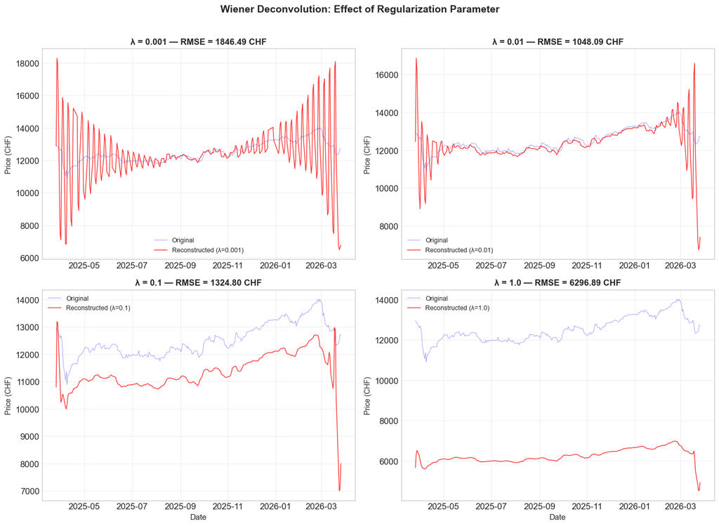

```python
# Visualization: Effect of regularization on reconstruction
fig, axes = plt.subplots(2, 2, figsize=(14, 10))

baseline_kernel = create_moving_average_kernel(5)
baseline_filtered = manual_convolve(price, baseline_kernel)

for i, lam in enumerate(regularizations):
    ax = axes[i // 2, i % 2]
    recon = wiener_deconvolution(baseline_filtered, baseline_kernel, lam)
    rmse = np.sqrt(np.mean((price - recon)**2))

    ax.plot(time_index, price, 'b-', linewidth=0.5, alpha=0.5, label='Original')
    ax.plot(time_index, recon, 'r-', linewidth=1, alpha=0.8,
            label=f'Reconstructed (λ={lam})')
    ax.set_title(f'λ = {lam} — RMSE = {rmse:.2f} CHF', fontsize=12, fontweight='bold')
    ax.legend(fontsize=9)
    ax.grid(True, alpha=0.3)
    ax.set_ylabel('Price (CHF)', fontsize=10)

axes[1, 0].set_xlabel('Date', fontsize=11)
axes[1, 1].set_xlabel('Date', fontsize=11)
plt.suptitle('Wiener Deconvolution: Effect of Regularization Parameter',
             fontsize=14, fontweight='bold', y=1.01)
plt.tight_layout()
plt.show()
```

### Consolidated Evaluation Results

[output not shown]

## Day 15 – Analysis & Communication

### Observations (3-5 sentences)

*Focus: Describe measurable results only — no explanation.*

### Interpretation (3-5 sentences)

*Focus: Explain what the results mean for the application.*

The reason Gaussian kernels outperform uniform (moving-average) kernels in feature retention is fundamentally a frequency-domain effect: the Gaussian's Fourier transform is itself a Gaussian, which means its attenuation profile rolls off smoothly without the side-lobe ringing inherent in the sinc-shaped spectrum of a rectangular window. Consequently, the Gaussian filter suppresses high-frequency noise while introducing less distortion in the passband frequencies that carry trend and peak information.

### Discussion and Critical Reflection (4-6 sentences)

*Focus: Relate the quantitative findings to the requirements of the defined use case and assess practical adequacy.*

**Outlook:** Beyond the methods tested here, promising directions include (1) **wavelet-based denoising**, which can adapt to non-stationary signal characteristics by decomposing the signal into time-frequency atoms; (2) **adaptive Wiener filtering**, where λ is estimated locally from the signal's time-varying SNR; and (3) **total-variation regularization**, which preserves sharp edges (trend reversals) while smoothing flat regions. Incorporating these approaches could significantly improve performance under the real-world constraints identified above.

### Final Reflections on MC1

> If repeating this work, I would reconsider using detrended returns instead of raw prices for the correlation analysis, as this could improve periodicity detection and reduce trend contamination. Certain challenges emerged during deconvolution parameter tuning, highlighting the importance of regularization in practical inverse problems.

> I was particularly impressed by the sensitivity of volatility estimation to sampling rate, especially how undersampling by just a factor of 5 significantly distorted risk metrics. Through this project, I learned that theoretical principles like the Nyquist theorem and linear convolution have direct, quantifiable consequences in applied domains, and I developed a clearer understanding of the trade-offs between signal fidelity, computational cost, and noise sensitivity.